# TP 5 : Importer, ranger et nettoyer des données

Rémi Pierron

2026-11-18

Dépôt GitHub du TP : https://github.com/remipierron/TP5_R

# Partie A : Importer des fichiers texte récalcitrants

## A1

Les cinq fichiers sont des fichiers texte **tabulés** avec un point décimal : on utilise donc `read.delim()`. Avant d’importer, on regarde les premières lignes de chaque fichier avec `readLines()` pour repérer leurs particularités.

```r
readLines("data/auto2004_original.txt", n = 3)
```

```
## [1] "Modele\tCylindree\tPuissance\tVitesse\tPoids\tLargeur\tLongueur"
## [2] "Citroen C2 1.1 Base\t1124\t61\t158\t932\t1659\t3666"
## [3] "Smart Fortwo Coupe\t698\t52\t135\t730\t1515\t2500"
```

```r
readLines("data/auto2004_original_ligne3.txt", n = 5, encoding = "latin1")
```

```
## [1] "Fichier auto"
## [2] "24 observations"
## [3] "1 variable caractère, 5 variables numériques"
## [4] "Modele\tCylindree\tPuissance\tVitesse\tPoids\tLargeur\tLongueur"
## [5] "Citroen C2 1.1 Base\t1124\t61\t158\t932\t1659\t3666"
```

```r
readLines("data/auto2004_sans_nom.txt", n = 2)
```

```
## [1] "Citroen C2 1.1 Base\t1124\t61\t158\t932\t1659\t3666"
## [2] "Smart Fortwo Coupe\t698\t52\t135\t730\t1515\t2500"
```

```r
readLines("data/auto2004_don_manquante.txt", n = 3)
```

```
## [1] "Modele\tCylindree\tPuissance\tVitesse\tPoids\tLargeur\tLongueur"
## [2] "Citroen C2 1.1 Base\t1124\t\t158\t932\t1659\t"
## [3] "Smart Fortwo Coupe\t698\t52\t\t730\t1515\t2500"
```

```r
readLines("data/auto2004_don_manquan_99999.txt", n = 3)
```

```
## [1] "Modele\tCylindree\tPuissance\tVitesse\tPoids\tLargeur\tLongueur"
## [2] "Citroen C2 1.1 Base\t1124\t99999\t158\t932\t1659\t99999"
## [3] "Smart Fortwo Coupe\t698\t52\t99999\t730\t1515\t2500"
```

Constats :

- `auto2004_original_ligne3.txt` : 3 lignes de description avant l’en-tête, et des accents encodés en latin1 (« caractère ») ;
- `auto2004_sans_nom.txt` : pas de ligne d’en-tête, la première ligne est déjà une voiture ;
- `auto2004_don_manquante.txt` : les valeurs manquantes sont des cases vides ;
- `auto2004_don_manquan_99999.txt` : les valeurs manquantes sont codées `99999` (sauf une case vide, la longueur de la Bentley).

```r
# a. Référence
ref <- read.delim("data/auto2004_original.txt")

# b. 3 lignes de description à sauter, fichier encodé en latin1
l3 <- read.delim("data/auto2004_original_ligne3.txt",
                 skip = 3, fileEncoding = "latin1")

# c. Pas d'en-tête : on reprend les noms de colonnes de la référence
sn <- read.delim("data/auto2004_sans_nom.txt",
                 header = FALSE, col.names = names(ref))

# d. Cases vides : converties en NA automatiquement dans les colonnes numériques
dm <- read.delim("data/auto2004_don_manquante.txt")

# e. 99999 est un code de valeur manquante
d99 <- read.delim("data/auto2004_don_manquan_99999.txt", na.strings = "99999")

str(ref)
```

```
## 'data.frame':    24 obs. of  7 variables:
##  $ Modele   : chr  "Citroen C2 1.1 Base" "Smart Fortwo Coupe" "Mini 1.6 170" "Nissan Micra 1.2 65" ...
##  $ Cylindree: int  1124 698 1598 1240 2946 1896 1398 2946 2685 2993 ...
##  $ Puissance: int  61 52 170 65 255 105 70 211 170 218 ...
##  $ Vitesse  : int  158 135 218 154 245 187 160 229 230 245 ...
##  $ Poids    : int  932 730 1215 965 1400 1295 1179 1640 1600 1595 ...
##  $ Largeur  : int  1659 1515 1690 1660 1810 1765 1746 1811 1728 1846 ...
##  $ Longueur : int  3666 2500 3625 3715 3812 4203 4202 4676 4528 4841 ...
```

Pour vérifier chaque import en **une** instruction, on compare en même temps les noms, les dimensions et les types (classe de chaque colonne) avec ceux de `ref` :

```r
# Une instruction (identical) par fichier, regroupées dans un vecteur nommé
meme_structure <- c(
  l3  = identical(list(names(l3),  dim(l3),  sapply(l3,  class)),
                  list(names(ref), dim(ref), sapply(ref, class))),
  sn  = identical(list(names(sn),  dim(sn),  sapply(sn,  class)),
                  list(names(ref), dim(ref), sapply(ref, class))),
  dm  = identical(list(names(dm),  dim(dm),  sapply(dm,  class)),
                  list(names(ref), dim(ref), sapply(ref, class))),
  d99 = identical(list(names(d99), dim(d99), sapply(d99, class)),
                  list(names(ref), dim(ref), sapply(ref, class)))
)
meme_structure
```

```
##   l3   sn   dm  d99
## TRUE TRUE TRUE TRUE
```

Pour les deux fichiers sans valeurs manquantes, on peut même vérifier que le contenu est strictement identique :

```r
all.equal(l3, ref)
```

```
## [1] TRUE
```

```r
all.equal(sn, ref)
```

```
## [1] TRUE
```

**Réponse :** 4 imports sur 4 renvoient `TRUE` : ils ont les mêmes noms, les mêmes dimensions (24 lignes, 7 colonnes) et les mêmes types (1 colonne(s) en `character` et 6 colonne(s) en `integer`) que la référence. Il a fallu `skip = 3` et `fileEncoding = "latin1"` pour le fichier avec description, `header = FALSE` et `col.names = names(ref)` pour le fichier sans en-tête, et `na.strings = "99999"` pour le fichier où les manquantes sont codées 99999 (sans cet argument les colonnes resteraient numériques mais contiendraient des valeurs aberrantes). Les fichiers `l3` et `sn` sont de plus identiques à `ref` en valeurs ; `dm` et `d99` ne diffèrent que par leurs valeurs manquantes.

## A2

### a. Nombre et positions des valeurs manquantes

```r
# Nombre total de NA dans chaque fichier
sum(is.na(dm))
```

```
## [1] 17
```

```r
sum(is.na(d99))
```

```
## [1] 17
```

```r
# Répartition par colonne
na_dm  <- colSums(is.na(dm))
na_d99 <- colSums(is.na(d99))
na_dm
```

```
##    Modele Cylindree Puissance   Vitesse     Poids   Largeur  Longueur
##         0         1         4         4         4         1         3
```

```r
na_d99
```

```
##    Modele Cylindree Puissance   Vitesse     Poids   Largeur  Longueur
##         0         1         4         4         4         1         3
```

```r
# Mêmes positions ? On compare les deux matrices logiques de is.na()
memes_positions <- identical(is.na(dm), is.na(d99))
memes_positions
```

```
## [1] TRUE
```

**Réponse :** `dm` contient **17 valeurs manquantes** et `d99` en contient **17** (répartition dans `dm` : 1 en Cylindree, 4 en Puissance, 4 en Vitesse, 4 en Poids, 1 en Largeur, 3 en Longueur ; aucune pour Modele). `identical()` renvoie `TRUE` : les deux matrices `is.na()` sont identiques, donc les valeurs manquantes sont **exactement aux mêmes positions** dans les deux fichiers.

### b. Valeurs originales des cases manquantes

`which(..., arr.ind = TRUE)` donne la ligne et la colonne de chaque case manquante. On s’en sert pour aller chercher dans `ref` le modèle et la valeur d’origine.

```r
pos <- which(is.na(dm), arr.ind = TRUE)   # matrice (ligne, colonne) des NA

manquantes <- data.frame(
  Modele           = ref$Modele[pos[, "row"]],
  variable         = names(ref)[pos[, "col"]],
  valeur_originale = ref[pos]               # indexation par matrice
)
manquantes[order(manquantes$Modele), ]
```

```
##                           Modele  variable valeur_originale
## 8          Aston Martin Vanquish   Vitesse              306
## 14         Aston Martin Vanquish   Largeur             1923
## 12              Audi TT 1.8T 180     Poids             1280
## 1         Bentley Continental GT Cylindree             5998
## 16        Bentley Continental GT  Longueur             4804
## 7                    BMW Z4 2.5i   Vitesse              235
## 11                   BMW Z4 2.5i     Poids             1260
## 2            Citroen C2 1.1 Base Puissance               61
## 15           Citroen C2 1.1 Base  Longueur             3666
## 17       Land Rover Defender Td5  Longueur             3883
## 13      Land Rover Discovery Td5     Poids             2175
## 3      Mercedes Classe C 270 CDI Puissance              170
## 4      Mercedes Classe S 400 CDI Puissance              260
## 10           Renault Clio 3.0 V6     Poids             1400
## 9     Renault Scenic 1.9 dCi 120   Vitesse              188
## 6             Smart Fortwo Coupe   Vitesse              135
## 5  Volkswagen Touran 1.9 TDI 105 Puissance              105
```

```r
# Voitures ayant plusieurs cases manquantes
nb_par_voiture <- table(manquantes$Modele)
nb_par_voiture[nb_par_voiture > 1]
```

```
##
##  Aston Martin Vanquish Bentley Continental GT            BMW Z4 2.5i
##                      2                      2                      2
##    Citroen C2 1.1 Base
##                      2
```

**Réponse :** 13 voitures sont concernées (17 cases manquantes). 4 voitures ont plusieurs valeurs manquantes : Aston Martin Vanquish (Vitesse 306 et Largeur 1923), Bentley Continental GT (Cylindree 5998 et Longueur 4804), BMW Z4 2.5i (Vitesse 235 et Poids 1260), Citroen C2 1.1 Base (Puissance 61 et Longueur 3666). Le tableau ci-dessus donne toutes les valeurs d’origine retrouvées dans `ref`.

### c. Puissance moyenne sans `na.strings`

```r
d99_brut <- read.delim("data/auto2004_don_manquan_99999.txt")   # sans na.strings
summary(d99_brut$Puissance)   # le max à 99999 trahit un code de valeur manquante
```

```
##    Min. 1st Qu.  Median    Mean 3rd Qu.    Max.
##    52.0   121.5   199.5 16848.3   485.0 99999.0
```

```r
moy_fausse <- mean(d99_brut$Puissance)
moy_juste  <- mean(d99$Puissance, na.rm = TRUE)
moy_ref    <- mean(ref$Puissance)
c(fausse = moy_fausse, juste = moy_juste, reference = moy_ref)
```

```
##     fausse      juste  reference
## 16848.3333   218.2000   206.6667
```

```r
moy_fausse - moy_juste   # écart absolu
```

```
## [1] 16630.13
```

```r
moy_fausse / moy_juste   # facteur d'erreur
```

```
## [1] 77.21509
```

**Réponse :** sans `na.strings`, les 4 valeurs `99999` sont comptées comme de vraies puissances et la moyenne vaut **16 848,3 ch** au lieu de **218,2 ch** (moyenne calculée sur les 20 puissances connues). On se trompe donc d’environ **16 630 ch**, soit une moyenne environ **77 fois trop grande**. Pour information, la vraie moyenne sur les 24 voitures (fichier `ref`) est de 206,7 ch : même en traitant correctement les NA, il reste un écart de 11,5 ch, car les voitures dont la puissance manque ne sont pas prises en compte.

## A3

On commence par regarder le fichier brut. Il est encodé en latin1 : on le précise à `readLines()` pour que les accents s’affichent correctement.

```r
readLines("data/stations_janvier2026.csv", n = 6, encoding = "latin1")
```

```
## [1] "# Relevés quotidiens - réseau fictif - janvier 2026"
## [2] "# Températures en °C, pluie en mm, vent en km/h"
## [3] "station;date;temp_min;temp_max;pluie_mm;vent_kmh"
## [4] "Orléans;01/01/2026;2,3;4,8;0,0;21"
## [5] "Orléans;02/01/2026;-1,7;5,2;0,0;12"
## [6] "Orléans;03/01/2026;1,3;6,2;5,5;14"
```

On cherche aussi les codes non numériques dans les colonnes de mesures (colonnes 3 à 6), qui sont probablement des codes de valeurs manquantes :

```r
brut <- readLines("data/stations_janvier2026.csv", encoding = "latin1")
champs  <- do.call(rbind, strsplit(brut[-(1:3)], ";"))  # sans commentaires ni en-tête
mesures <- champs[, 3:6]                                  # colonnes de mesures
codes_na <- table(mesures[!grepl("^-?[0-9]+(,[0-9]+)?$", mesures)])  # ce qui n'est pas un nombre
codes_na
```

```
##
##   - n/a
##   5   6
```

Particularités du fichier :

- **lignes de commentaire** : les 2 premières lignes commencent par `#` ;
- **séparateur** de colonnes : `;` ;
- **décimale** : la virgule (`2,3`) ;
- **encodage** : latin1 (Windows), visible sur « Orléans » ou « Saint-Étienne » ;
- **valeurs manquantes** : codées `-` et `n/a` ;
- **dates** au format `jj/mm/aaaa` (`01/01/2026`).

### a. Import avec readr

```r
meteo <- read_delim(
  "data/stations_janvier2026.csv",
  delim   = ";",                              # séparateur de colonnes
  comment = "#",                              # ignore les lignes de commentaire
  na      = c("", "NA", "-", "n/a"),          # codes de valeurs manquantes
  locale  = locale(decimal_mark = ",",        # virgule décimale
                   encoding = "latin1"),      # fichier Windows
  col_types = cols(
    station  = col_character(),
    date     = col_date(format = "%d/%m/%Y"), # jour/mois/année
    .default = col_double()                   # températures, pluie, vent
  )
)
meteo
```

```
## # A tibble: 124 × 6
##    station date       temp_min temp_max pluie_mm vent_kmh
##    <chr>   <date>        <dbl>    <dbl>    <dbl>    <dbl>
##  1 Orléans 2026-01-01      2.3      4.8      0         21
##  2 Orléans 2026-01-02     -1.7      5.2      0         12
##  3 Orléans 2026-01-03      1.3      6.2      5.5       14
##  4 Orléans 2026-01-04      0.8      6.5      0         34
##  5 Orléans 2026-01-05     -0.7      6.4      1.2       12
##  6 Orléans 2026-01-06     -5.3      2.8      0          9
##  7 Orléans 2026-01-07     -0.8      5.1      0         17
##  8 Orléans 2026-01-08     -1.6      9.7      3.8       20
##  9 Orléans 2026-01-09      1.3      8.5     12.2       30
## 10 Orléans 2026-01-10     -0.2      5.4      2.6       25
## # ℹ 114 more rows
```

```r
problems(meteo)   # aucune ligne mal lue
```

```
## # A tibble: 0 × 5
## # ℹ 5 variables: row <int>, col <int>, expected <chr>, actual <chr>, file <chr>
```

### b. Vérifications

```r
dim(meteo)                       # dimensions
```

```
## [1] 124   6
```

```r
sapply(meteo, class)             # types
```

```
##     station        date    temp_min    temp_max    pluie_mm    vent_kmh
## "character"      "Date"   "numeric"   "numeric"   "numeric"   "numeric"
```

```r
colSums(is.na(meteo))            # NA par colonne
```

```
##  station     date temp_min temp_max pluie_mm vent_kmh
##        0        0        0        6        0        5
```

```r
range(meteo$date)                # période couverte
```

```
## [1] "2026-01-01" "2026-01-31"
```

```r
count(meteo, station)            # noms des stations et nombre de jours
```

```
## # A tibble: 4 × 2
##   station           n
##   <chr>         <int>
## 1 Besançon         31
## 2 Nîmes            31
## 3 Orléans          31
## 4 Saint-Étienne    31
```

**Réponse :** `meteo` contient **124 lignes et 6 colonnes**, et `problems()` ne signale aucune ligne mal lue (0 problème). Les types sont corrects : `date` est de classe `Date`, `station` de classe `character`, et les colonnes temp_min, temp_max, pluie_mm, vent_kmh sont numériques. Il y a **11 valeurs manquantes** : 6 dans temp_max et 5 dans vent_kmh, aucune ailleurs. La période couverte va du 01/01/2026 au 31/01/2026 (31 jours). Les 4 stations s’affichent avec leurs accents (Besançon, Nîmes, Orléans, Saint-Étienne) et ont chacune 31 jours de relevés.

## A4

### a. Bilan par station

`temp_max` contient des valeurs manquantes : on utilise `na.rm = TRUE` dans tous les résumés (sinon la moyenne de la station concernée vaudrait `NA`).

```r
bilan_meteo <- meteo |>
  summarise(
    temp_min_moy = mean(temp_min, na.rm = TRUE),        # température minimale moyenne
    temp_max_moy = mean(temp_max, na.rm = TRUE),        # température maximale moyenne
    pluie_cumul  = sum(pluie_mm, na.rm = TRUE),         # cumul de pluie (mm)
    jours_gel    = sum(temp_min < 0, na.rm = TRUE),     # nb de jours où temp_min < 0
    jours_pluie  = sum(pluie_mm > 0, na.rm = TRUE),     # nb de jours où pluie_mm > 0
    .by = station
  )
bilan_meteo
```

```
## # A tibble: 4 × 6
##   station       temp_min_moy temp_max_moy pluie_cumul jours_gel jours_pluie
##   <chr>                <dbl>        <dbl>       <dbl>     <int>       <int>
## 1 Orléans              0.774         7.07        50.8        11          11
## 2 Besançon            -2.32          3.91        69.6        28          19
## 3 Nîmes                5.01         11.0         99           0          15
## 4 Saint-Étienne       -1.07          5.26        76.1        20          13
```

`sum()` sur une condition logique compte les `TRUE` : c’est ce qui donne directement un nombre de jours.

### b. Station la plus gelée, station la plus pluvieuse

```r
plus_gel   <- bilan_meteo |> slice_max(jours_gel, n = 1)
plus_pluie <- bilan_meteo |> slice_max(pluie_cumul, n = 1)
plus_jours_pluie <- bilan_meteo |> slice_max(jours_pluie, n = 1)

plus_gel         |> select(station, jours_gel)
```

```
## # A tibble: 1 × 2
##   station  jours_gel
##   <chr>        <int>
## 1 Besançon        28
```

```r
plus_pluie       |> select(station, pluie_cumul)
```

```
## # A tibble: 1 × 2
##   station pluie_cumul
##   <chr>         <dbl>
## 1 Nîmes            99
```

```r
plus_jours_pluie |> select(station, jours_pluie)
```

```
## # A tibble: 1 × 2
##   station  jours_pluie
##   <chr>          <int>
## 1 Besançon          19
```

**Réponse :** la station qui a connu le plus de jours de gel est **Besançon**, avec 28 jours de gel sur 31 (pour une température minimale moyenne de -2,3 °C). La station qui a reçu le plus de pluie en cumul est **Nîmes**, avec 99,0 mm sur le mois, bien que ce ne soit pas la station où il a plu le plus souvent : c’est Besançon qui compte le plus de jours de pluie (19 jours, contre 15 à Nîmes).

### c. Jour le plus froid de chaque station

On prend le jour où la température **minimale** est la plus basse.

```r
jour_froid <- meteo |>
  slice_min(temp_min, n = 1, by = station) |>   # ex aequo éventuels conservés
  select(station, date, temp_min)
jour_froid
```

```
## # A tibble: 4 × 3
##   station       date       temp_min
##   <chr>         <date>        <dbl>
## 1 Orléans       2026-01-15     -5.4
## 2 Besançon      2026-01-26     -5.1
## 3 Nîmes         2026-01-29      0.1
## 4 Saint-Étienne 2026-01-02     -5.6
```

**Réponse :** le jour le plus froid de chaque station est : Orléans le 15/01/2026 (-5,4 °C), Besançon le 26/01/2026 (-5,1 °C), Nîmes le 29/01/2026 (0,1 °C), Saint-Étienne le 02/01/2026 (-5,6 °C).

## A5

Les trois instructions à déboguer (non exécutées ici) :

```r
p1 <- read.csv("data/prix_fr.csv")
p2 <- read.csv2("data/prix_fr.csv")
p3 <- read_csv2("data/prix_fr.csv", na = "n/a", skip = 1)
```

### Diagnostic sans exécuter

Le fichier `prix_fr.csv` est un CSV « à la française » : séparateur `;`, virgule décimale, une ligne d’en-tête, et un stock manquant codé `n/a` (voir le cours, diapo « Avant d’importer »).

- **`p1`** : `read.csv()` attend un séparateur `,` et un point décimal. Le `;` n’est pas reconnu, donc l’en-tête `produit;prix;stock;categorie` devient **une seule colonne**. En plus, la virgule décimale des prix (`24,90`) est prise pour un séparateur : chaque ligne est coupée en deux au milieu du prix.
- **`p2`** : `read.csv2()` est la bonne fonction (`;` et `,`), mais le code `n/a` n’est pas déclaré comme valeur manquante. Une colonne numérique qui contient du texte est lue entièrement en texte : **`stock` sera de type `character`** au lieu d’entier.
- **`p3`** : `na = "n/a"` est correct, mais **`skip = 1` saute la ligne d’en-tête**. La première ligne de données (« Raquette junior ») sert alors de noms de colonnes : on perd une ligne et les colonnes portent des noms absurdes (`Raquette junior`, `24,90`…). De plus, `na = "n/a"` remplace la valeur par défaut `c("", "NA")` : les cases vides ne seraient plus des `NA`.

### Vérification

```r
readLines("data/prix_fr.csv")   # le fichier brut
```

```
## [1] "produit;prix;stock;categorie"        "Raquette junior;24,90;12;tennis"
## [3] "Ballon taille 5;18,50;40;football"   "Maillot réplique;59,99;n/a;football"
## [5] "Chaussures trail;89,00;7;running"    "Gourde isotherme;14,95;25;running"
```

```r
p1 <- read.csv("data/prix_fr.csv")
str(p1)
```

```
## 'data.frame':    5 obs. of  1 variable:
##  $ produit.prix.stock.categorie: chr  "90;12;tennis" "50;40;football" "99;n/a;football" "00;7;running" ...
```

```r
rownames(p1)                    # le début de chaque ligne est devenu un nom de ligne
```

```
## [1] "Raquette junior;24"  "Ballon taille 5;18"  "Maillot réplique;59"
## [4] "Chaussures trail;89" "Gourde isotherme;14"
```

```r
p2 <- read.csv2("data/prix_fr.csv")
str(p2)
```

```
## 'data.frame':    5 obs. of  4 variables:
##  $ produit  : chr  "Raquette junior" "Ballon taille 5" "Maillot réplique" "Chaussures trail" ...
##  $ prix     : num  24.9 18.5 60 89 14.9
##  $ stock    : chr  "12" "40" "n/a" "7" ...
##  $ categorie: chr  "tennis" "football" "football" "running" ...
```

```r
p3 <- read_csv2("data/prix_fr.csv", na = "n/a", skip = 1, show_col_types = FALSE)
```

```
## ℹ Using "','" as decimal and "'.'" as grouping mark. Use `read_delim()` for more control.
```

```r
p3
```

```
## # A tibble: 4 × 4
##   `Raquette junior` `24,90`  `12` tennis
##   <chr>               <dbl> <dbl> <chr>
## 1 Ballon taille 5      18.5    40 football
## 2 Maillot réplique     60.0    NA football
## 3 Chaussures trail     89       7 running
## 4 Gourde isotherme     15.0    25 running
```

Les résultats confirment le diagnostic :

- `p1` n’a que **1 colonne** (`produit.prix.stock.categorie`) ; comme les lignes de données ont un champ de plus que l’en-tête (à cause de la virgule des prix), `read.csv()` a même utilisé le premier morceau (`Raquette junior;24`) comme **nom de ligne** ;
- dans `p2`, `stock` est de classe **`character`** ;
- `p3` n’a que **4 lignes** au lieu de 5, et ses noms de colonnes sont `Raquette junior`, `24,90`, `12`, `tennis`.

### Correction

```r
# p1 : bonne fonction pour un CSV français + code n/a
p1 <- read.csv("data/prix_fr.csv", sep = ";", dec = ",", na.strings = "n/a")

# p2 : on déclare le code de valeur manquante
p2 <- read.csv2("data/prix_fr.csv", na.strings = "n/a")

# p3 : pas de skip, et on garde les codes NA par défaut en plus de "n/a"
p3 <- read_csv2("data/prix_fr.csv", na = c("", "NA", "n/a"), show_col_types = FALSE)
```

```
## ℹ Using "','" as decimal and "'.'" as grouping mark. Use `read_delim()` for more control.
```

```r
str(p1)
```

```
## 'data.frame':    5 obs. of  4 variables:
##  $ produit  : chr  "Raquette junior" "Ballon taille 5" "Maillot réplique" "Chaussures trail" ...
##  $ prix     : num  24.9 18.5 60 89 14.9
##  $ stock    : int  12 40 NA 7 25
##  $ categorie: chr  "tennis" "football" "football" "running" ...
```

```r
str(p2)
```

```
## 'data.frame':    5 obs. of  4 variables:
##  $ produit  : chr  "Raquette junior" "Ballon taille 5" "Maillot réplique" "Chaussures trail" ...
##  $ prix     : num  24.9 18.5 60 89 14.9
##  $ stock    : int  12 40 NA 7 25
##  $ categorie: chr  "tennis" "football" "football" "running" ...
```

```r
p3
```

```
## # A tibble: 5 × 4
##   produit           prix stock categorie
##   <chr>            <dbl> <dbl> <chr>
## 1 Raquette junior   24.9    12 tennis
## 2 Ballon taille 5   18.5    40 football
## 3 Maillot réplique  60.0    NA football
## 4 Chaussures trail  89       7 running
## 5 Gourde isotherme  15.0    25 running
```

```r
# Les trois imports donnent-ils le même tableau ? (p3 est un tibble, stock y est en double)
all.equal(p1, p2)
```

```
## [1] TRUE
```

```r
all.equal(p2, as.data.frame(p3), check.attributes = FALSE)
```

```
## [1] TRUE
```

**Réponse :** les trois erreurs sont : `p1` utilise le mauvais séparateur et la mauvaise décimale (il faut `read.csv2()` ou `sep = ";", dec = ","`) ; `p2` ne déclare pas le code `n/a` (il faut `na.strings = "n/a"`) ; `p3` saute à tort la ligne d’en-tête avec `skip = 1`. Une fois corrigés, les trois imports ont 5 lignes et 4 colonnes, `prix` et `stock` sont numériques avec 1 stock manquant (Maillot réplique), et les trois tableaux ont les mêmes valeurs (à la classe près : `p3` est un tibble et son `stock` est de type `double` alors qu’il est de type `integer` dans `p2`).

# Partie B : Excel, SAS et export

## B1

### a. Feuilles du classeur et début du tableau

```r
fichier_pluie <- "data/pluie_mensuelle.xlsx"
feuilles <- excel_sheets(fichier_pluie)
feuilles
```

```
## [1] "2024" "2025"
```

```r
# Aperçu brut de la première feuille, sans en-tête, pour voir où commence le tableau
brut_pluie <- read_excel(fichier_pluie, sheet = feuilles[1],
                         col_names = FALSE, .name_repair = "minimal")
brut_pluie[, 1:4]
```

```
## # A tibble: 8 × 4
##   ``                                 ``    ``    ``
##   <chr>                              <chr> <chr> <chr>
## 1 Cumul de pluie mensuel (mm) - 2024 <NA>  <NA>  <NA>
## 2 Source : réseau fictif             <NA>  <NA>  <NA>
## 3 <NA>                               <NA>  <NA>  <NA>
## 4 station                            janv  févr  mars
## 5 Orléans                            62    69    15
## 6 Besançon                           66    18    28
## 7 Nîmes                              78    78    27
## 8 Saint-Étienne                      80    52    69
```

```r
# Ligne où se trouve l'en-tête "station"
ligne_entete <- which(brut_pluie[[1]] == "station")
ligne_entete
```

```
## [1] 4
```

**Réponse :** le classeur contient 2 feuilles, une par année : 2024 et 2025. Dans chaque feuille, les premières lignes ne font pas partie du tableau : un titre (« Cumul de pluie mensuel (mm) - 2024 »), une source (« Source : réseau fictif ») puis une ligne vide. Le tableau commence à la **ligne 4** (cellule `A4`), qui contient l’en-tête `station`, `janv`, …, `déc`. Il faut donc sauter **3 lignes** à l’import (`skip = 3`).

### b. Import des deux feuilles et empilement

On lit chaque feuille avec le même `skip`, dans une liste nommée par l’année, puis `bind_rows(.id = "annee")` empile les tableaux en ajoutant une colonne qui indique la feuille d’origine.

```r
liste_pluie <- lapply(feuilles, function(f) {
  read_excel(fichier_pluie, sheet = f, skip = ligne_entete - 1)
})
names(liste_pluie) <- feuilles

# Les deux feuilles ont-elles les mêmes colonnes ?
identical(names(liste_pluie[[1]]), names(liste_pluie[[2]]))
```

```
## [1] TRUE
```

```r
pluie <- bind_rows(liste_pluie, .id = "annee") |>
  mutate(annee = as.numeric(annee))   # le nom de la feuille est du texte : on le convertit

pluie
```

```
## # A tibble: 8 × 14
##   annee station       janv  févr  mars   avr   mai  juin  juil  août  sept   oct
##   <dbl> <chr>        <dbl> <dbl> <dbl> <dbl> <dbl> <dbl> <dbl> <dbl> <dbl> <dbl>
## 1  2024 Orléans         62    69    15    43    48    57    54    75    55   137
## 2  2024 Besançon        66    18    28    48    47    59    56    83    75    66
## 3  2024 Nîmes           78    78    27    26    55    67   140    40    71    36
## 4  2024 Saint-Étien…    80    52    69    58    70    17    31    58    41    59
## 5  2025 Orléans         20    29    71    96    81    99   139    71    55    87
## 6  2025 Besançon       220    34    28    57    31    45    13    46    35    45
## 7  2025 Nîmes           79     9    36    31    22    25    54    52    29    28
## 8  2025 Saint-Étien…    72    78    41    56    65    36    16    35    78    39
## # ℹ 2 more variables: nov <dbl>, déc <dbl>
```

```r
class(pluie$annee)
```

```
## [1] "numeric"
```

**Réponse :** `pluie` est un tibble de 8 lignes (4 stations × 2 années) et 14 colonnes : `annee` (de classe `numeric`), `station` et les 12 mois.

### c. Cumul annuel par station

On additionne les 12 colonnes de mois ligne par ligne avec `rowSums()`.

```r
cumul_annuel <- pluie |>
  mutate(cumul = rowSums(across(janv:déc), na.rm = TRUE)) |>
  select(annee, station, cumul)
cumul_annuel
```

```
## # A tibble: 8 × 3
##   annee station       cumul
##   <dbl> <chr>         <dbl>
## 1  2024 Orléans         663
## 2  2024 Besançon        626
## 3  2024 Nîmes           674
## 4  2024 Saint-Étienne   651
## 5  2025 Orléans         863
## 6  2025 Besançon        753
## 7  2025 Nîmes           419
## 8  2025 Saint-Étienne   677
```

```r
# Présentation plus lisible : une colonne par année
cumul_large <- cumul_annuel |>
  pivot_wider(names_from = annee, values_from = cumul)
cumul_large
```

```
## # A tibble: 4 × 3
##   station       `2024` `2025`
##   <chr>          <dbl>  <dbl>
## 1 Orléans          663    863
## 2 Besançon         626    753
## 3 Nîmes            674    419
## 4 Saint-Étienne    651    677
```

**Réponse :** les cumuls annuels sont donnés dans le tableau ci-dessus. En 2024, la station la plus arrosée est Nîmes (674 mm) et la moins arrosée Besançon (626 mm). En 2025, la station la plus arrosée est Orléans (863 mm) et la moins arrosée Nîmes (419 mm).

## B2

### a. Import avec haven

```r
library(haven)

pays <- read_sas("data/paysniv3.sas7bdat")
dim(pays)
```

```
## [1] 173  25
```

```r
glimpse(pays)
```

```
## Rows: 173
## Columns: 25
## $ NOM   <chr> "ALGERIA", "EGYPT", "LIBYA", "MOROCCO", "SUDAN", "TUNISIA", "BEN…
## $ POP87 <dbl> 23.5, 51.9, 3.8, 24.4, 23.5, 7.6, 4.3, 7.3, 0.3, 10.8, 0.8, 13.9…
## $ NAT   <dbl> 42, 37, 39, 36, 45, 32, 51, 48, 35, 46, 49, 42, 47, 41, 48, 51, …
## $ MORT  <dbl> 10, 11, 9, 10, 16, 7, 20, 20, 8, 15, 28, 14, 23, 21, 16, 22, 20,…
## $ ACCR  <dbl> 3.2, 2.6, 3.0, 2.5, 2.8, 2.5, 3.0, 2.8, 2.6, 3.0, 2.1, 2.8, 2.4,…
## $ DOUB  <dbl> 22, 26, 23, 27, 24, 27, 23, 25, 26, 23, 33, 25, 29, 35, 22, 24, …
## $ POP00 <dbl> 33.7, 71.2, 5.6, 33.3, 33.4, 9.9, 7.1, 10.5, 0.5, 17.3, 1.1, 20.…
## $ POP20 <dbl> 49.4, 103.0, 8.4, 48.5, 55.6, 13.6, 14.2, 18.2, 0.7, 32.1, 1.8, …
## $ MORTI <dbl> 81.0, 93.0, 90.0, 90.0, 112.0, 78.0, 115.0, 146.0, 76.5, 105.0, …
## $ FERTI <dbl> 6.4, 5.3, 5.6, 4.8, 6.5, 4.5, 7.1, 6.5, 5.1, 6.7, 6.4, 5.8, 6.2,…
## $ AGE15 <dbl> 46, 40, 45, 42, 45, 40, 49, 44, 46, 46, 46, 47, 43, 44, 47, 46, …
## $ AGE65 <dbl> 4, 4, 3, 4, 3, 4, 5, 3, 6, 3, 3, 3, 3, 4, 3, 3, 3, 3, 2, 3, 3, 3…
## $ ESPER <dbl> 60, 59, 61, 60, 49, 62, 45, 46, 60, 52, 36, 54, 41, 44, 50, 43, …
## $ URBA  <dbl> 43, 46, 76, 43, 20, 53, 39, 8, 27, 43, 21, 31, 22, 27, 40, 18, 3…
## $ EAU   <dbl> 90, 75, 98, NA, 48, NA, 20, 30, NA, 20, NA, 43, 17, 33, 40, 14, …
## $ ENERG <dbl> 21, 19, 111, 9, 2, 20, 1, 1, 6, 6, 3, 2, 2, 1, 10, 1, 5, 2, 7, 5…
## $ ENERT <dbl> 95, 142, 463, 69, -46, 137, -14, 125, NA, 5, 49, -55, -28, -40, …
## $ PNB   <dbl> 2530, 680, 7500, 610, 330, 1220, 270, 140, 430, 620, 230, 390, 3…
## $ SURF  <dbl> 2381740.69, 1001449.40, 1759539.81, 446549.67, 2505809.46, 16361…
## $ CULTU <dbl> 3, 2, 1, 19, 5, 29, 16, 10, 10, 12, 15, 12, 6, 8, 3, 2, 0, 3, 34…
## $ PATUR <dbl> 13, 0, 8, 28, 22, 18, 4, 36, 6, 9, 8, 14, 12, 35, 2, 24, 38, 7, …
## $ FORET <dbl> 2, 0, 0, 12, 19, 3, 33, 2, 0, 24, 17, 3, 42, 30, 34, 7, 15, 2, 1…
## $ PAYS  <chr> "ALGE", "EGYP", "LIBY", "MARO", "SOUD", "TUNI", "BENI", "BURK", …
## $ NIV   <dbl> 3, 3, 3, 3, 3, 3, 3, 3, 3, 3, 3, 3, 3, 3, 3, 3, 3, 3, 3, 3, 3, 3…
## $ CONTI <dbl> 1, 1, 1, 1, 1, 1, 1, 1, 1, 1, 1, 1, 1, 1, 1, 1, 1, 1, 1, 1, 1, 1…
```

```r
# Nombre de valeurs manquantes par variable (seulement celles qui en ont)
na_pays <- colSums(is.na(pays))
na_pays[na_pays > 0]
```

```
##  DOUB  URBA   EAU ENERG ENERT   PNB  SURF CULTU PATUR FORET
##     4     3    90    36    35    10     1     2     2     2
```

```r
# Variables décrites dans l'énoncé
vars_enonce <- c("NOM", "CONTI", "ESPER", "FERTI", "MORTI", "PNB", "URBA")
na_pays[vars_enonce]
```

```
##   NOM CONTI ESPER FERTI MORTI   PNB  URBA
##     0     0     0     0     0    10     3
```

**Réponse :** le fichier décrit **173 pays** avec **25 variables**. 10 variables ont des valeurs manquantes : DOUB (4), URBA (3), EAU (90), ENERG (36), ENERT (35), PNB (10), SURF (1), CULTU (2), PATUR (2), FORET (2). La plus touchée est EAU, avec 90 pays sans valeur, soit 52 % des pays. Parmi les variables présentées dans l’énoncé, PNB et URBA ont des manquantes ; NOM, CONTI, ESPER, FERTI, MORTI sont complètes.

### b. CONTI en facteur

`CONTI` est importé comme un simple nombre (`numeric`), sans étiquettes SAS : on construit le facteur avec `factor()` en donnant les codes (`levels`) et les noms correspondants (`labels`), dans l’ordre de l’énoncé.

```r
pays <- pays |>
  mutate(continent = factor(CONTI,
                            levels = 1:5,
                            labels = c("Afrique", "Asie", "Amériques",
                                       "Europe", "Océanie")))

# Vérification : chaque code correspond bien à un seul continent
count(pays, CONTI, continent)
```

```
## # A tibble: 5 × 3
##   CONTI continent     n
##   <dbl> <fct>     <int>
## 1     1 Afrique      53
## 2     2 Asie         44
## 3     3 Amériques    39
## 4     4 Europe       28
## 5     5 Océanie       9
```

```r
class(pays$continent)
```

```
## [1] "factor"
```

On garde `CONTI` à côté de la nouvelle colonne `continent` pour pouvoir vérifier la correspondance.

### c. Résumé par continent

`PNB` contient des valeurs manquantes, d’où `na.rm = TRUE`.

```r
resume_continent <- pays |>
  summarise(
    nb_pays   = n(),
    esper_moy = mean(ESPER, na.rm = TRUE),
    ferti_moy = mean(FERTI, na.rm = TRUE),
    pnb_med   = median(PNB, na.rm = TRUE),
    .by = continent
  ) |>
  arrange(esper_moy)
resume_continent
```

```
## # A tibble: 5 × 5
##   continent nb_pays esper_moy ferti_moy pnb_med
##   <fct>       <int>     <dbl>     <dbl>   <dbl>
## 1 Afrique        53      50.8      6.11     370
## 2 Asie           44      60.8      4.88    1150
## 3 Océanie         9      67.9      4.06    1700
## 4 Amériques      39      68.4      3.43    1320
## 5 Europe         28      73.5      1.87    8335
```

**Réponse :** du continent où l’espérance de vie moyenne est la plus basse au plus élevé : Afrique (50,8 ans), Asie (60,8 ans), Océanie (67,9 ans), Amériques (68,4 ans), Europe (73,5 ans). L’écart entre Afrique et Europe atteint 22,7 ans. La fécondité suit l’ordre inverse : 6,1 enfants par femme en Afrique contre 1,9 en Europe. Le PNB médian par habitant va de 370 dollars (Afrique) à 8 335 dollars (Europe). Le PNB médian ne suit cependant pas exactement l’ordre de l’espérance de vie : Océanie a une espérance de vie moyenne plus basse que Amériques mais un PNB médian plus élevé (1 700 contre 1 320 dollars).

### d. Les 5 pays à l’espérance de vie la plus basse

```r
esper_basse <- pays |>
  slice_min(ESPER, n = 5) |>   # with_ties = TRUE par défaut : les ex aequo sont gardés
  select(NOM, continent, ESPER)
esper_basse
```

```
## # A tibble: 7 × 3
##   NOM          continent ESPER
##   <chr>        <fct>     <dbl>
## 1 SIERRA LEONE Afrique      35
## 2 GAMBIA       Afrique      36
## 3 AFGANISTHAN  Asie         39
## 4 EAST TIMOR   Asie         40
## 5 GUINEA       Afrique      41
## 6 ETHIOPIA     Afrique      41
## 7 SOMALIA      Afrique      41
```

**Réponse :** les pays où l’espérance de vie est la plus basse sont SIERRA LEONE (35 ans), GAMBIA (36 ans), AFGANISTHAN (39 ans), EAST TIMOR (40 ans), GUINEA (41 ans), ETHIOPIA (41 ans), SOMALIA (41 ans). Le tableau compte 7 pays et non 5, car 3 pays sont ex aequo à la 5e place avec 41 ans (GUINEA, ETHIOPIA, SOMALIA) : on les garde tous plutôt que d’en choisir un arbitrairement. 5 de ces 7 pays sont en Afrique.

## B3

Tous les fichiers produits vont dans le dossier `sorties/`, qui est ignoré par git (voir `.gitignore`).

```r
dir.create("sorties", showWarnings = FALSE)
```

### a. Export de `bilan_meteo` en CSV « à la française »

`write_csv2()` écrit un CSV avec `;` comme séparateur et `,` comme décimale, lisible directement par un Excel français.

```r
write_csv2(bilan_meteo, "sorties/bilan_meteo.csv")

readLines("sorties/bilan_meteo.csv")   # contenu brut du fichier
```

```
## [1] "station;temp_min_moy;temp_max_moy;pluie_cumul;jours_gel;jours_pluie"
## [2] "Orléans;0,774193548387097;7,06551724137931;50,8;11;11"
## [3] "Besançon;-2,316129032258064;3,90666666666667;69,6;28;19"
## [4] "Nîmes;5,006451612903226;11,04137931034483;99,0;0;15"
## [5] "Saint-Étienne;-1,067741935483871;5,25666666666667;76,1;20;13"
```

```r
bilan_relu <- read_csv2("sorties/bilan_meteo.csv", show_col_types = FALSE)
```

```
## ℹ Using "','" as decimal and "'.'" as grouping mark. Use `read_delim()` for more control.
```

```r
bilan_relu
```

```
## # A tibble: 4 × 6
##   station       temp_min_moy temp_max_moy pluie_cumul jours_gel jours_pluie
##   <chr>                <dbl>        <dbl>       <dbl>     <dbl>       <dbl>
## 1 Orléans              0.774         7.07        50.8        11          11
## 2 Besançon            -2.32          3.91        69.6        28          19
## 3 Nîmes                5.01         11.0         99           0          15
## 4 Saint-Étienne       -1.07          5.26        76.1        20          13
```

```r
# Même tableau ?
identical(bilan_meteo, bilan_relu)                            # strictement identique ?
```

```
## [1] FALSE
```

```r
all.equal(bilan_meteo, bilan_relu, check.attributes = FALSE)  # mêmes valeurs ?
```

```
## [1] TRUE
```

```r
sapply(bilan_meteo, class)
```

```
##      station temp_min_moy temp_max_moy  pluie_cumul    jours_gel  jours_pluie
##  "character"    "numeric"    "numeric"    "numeric"    "integer"    "integer"
```

```r
sapply(bilan_relu, class)
```

```
##      station temp_min_moy temp_max_moy  pluie_cumul    jours_gel  jours_pluie
##  "character"    "numeric"    "numeric"    "numeric"    "numeric"    "numeric"
```

```r
max(abs(bilan_meteo$temp_min_moy - bilan_relu$temp_min_moy))  # écart numérique
```

```
## [1] 4.440892e-16
```

**Réponse :** `identical()` renvoie `FALSE` : le tableau relu n’est pas strictement le même objet. En revanche, `all.equal()` sans les attributs renvoie `TRUE` : on retrouve les mêmes valeurs, les mêmes noms de colonnes et les mêmes stations avec leurs accents. Les différences viennent de ce qu’un CSV ne stocke que du texte : les colonnes `jours_gel` et `jours_pluie` passent de integer à numeric (readr lit tout nombre en double), readr ajoute ses propres attributs (`spec`, `problems`) au tibble relu, et les moyennes sont écrites avec 15 chiffres significatifs, d’où un écart d’arrondi négligeable (4.4e-16).

### b. Un seul fichier Excel, deux feuilles

`writexl::write_xlsx()` accepte une **liste nommée** de tableaux : chaque élément devient une feuille portant son nom.

```r
writexl::write_xlsx(list(pluie = pluie, bilan_meteo = bilan_meteo),
                    "sorties/pluie_et_meteo.xlsx")

# Vérification : feuilles du classeur et relecture
excel_sheets("sorties/pluie_et_meteo.xlsx")
```

```
## [1] "pluie"       "bilan_meteo"
```

```r
read_excel("sorties/pluie_et_meteo.xlsx", sheet = "bilan_meteo")
```

```
## # A tibble: 4 × 6
##   station       temp_min_moy temp_max_moy pluie_cumul jours_gel jours_pluie
##   <chr>                <dbl>        <dbl>       <dbl>     <dbl>       <dbl>
## 1 Orléans              0.774         7.07        50.8        11          11
## 2 Besançon            -2.32          3.91        69.6        28          19
## 3 Nîmes                5.01         11.0         99           0          15
## 4 Saint-Étienne       -1.07          5.26        76.1        20          13
```

**Réponse :** le fichier `sorties/pluie_et_meteo.xlsx` contient 2 feuilles : pluie et bilan_meteo.

### c. Sauvegarde de `pays` en `.rds`

```r
saveRDS(pays, "sorties/pays.rds")
pays_relu <- readRDS("sorties/pays.rds")

class(pays_relu$continent)
```

```
## [1] "factor"
```

```r
levels(pays_relu$continent)
```

```
## [1] "Afrique"   "Asie"      "Amériques" "Europe"    "Océanie"
```

```r
identical(pays, pays_relu)      # l'objet est-il retrouvé à l'identique ?
```

```
## [1] TRUE
```

Et avec un CSV :

```r
write_csv(pays, "sorties/pays.csv")
pays_csv <- read_csv("sorties/pays.csv", show_col_types = FALSE)

class(pays_csv$continent)
```

```
## [1] "character"
```

```r
# Si on refait un facteur sans préciser les niveaux, ils sont triés par ordre alphabétique
levels(factor(pays_csv$continent))
```

```
## [1] "Afrique"   "Amériques" "Asie"      "Europe"    "Océanie"
```

**Réponse :** après `saveRDS()` / `readRDS()`, `continent` est toujours de classe `factor`, avec ses 5 niveaux dans l’ordre d’origine (Afrique, Asie, Amériques, Europe, Océanie), et `identical()` renvoie `TRUE` : le `.rds` conserve l’objet R tel quel. Avec un CSV, qui ne contient que du texte, `continent` redevient une simple chaîne de caractères (`character`) : la notion de facteur et l’ordre des niveaux sont perdus. Il faudrait refaire `factor()` à la relecture, et sans `levels` explicites l’ordre deviendrait alphabétique (Afrique, Amériques, Asie, Europe, Océanie) au lieu de l’ordre des codes 1 à 5.

# Partie C : Ranger les données (tidy data)

## C1

### a. `pluie` au format long

Dans `pluie`, les mois sont dans les noms de colonnes : le tableau n’est pas rangé. `pivot_longer()` empile les 12 colonnes de mois en deux colonnes, `mois` (le nom de la colonne) et `mm` (la valeur).

```r
pluie_long <- pluie |>
  pivot_longer(cols      = janv:déc,   # les 12 colonnes de mois
               names_to  = "mois",
               values_to = "mm")
pluie_long
```

```
## # A tibble: 96 × 4
##    annee station mois     mm
##    <dbl> <chr>   <chr> <dbl>
##  1  2024 Orléans janv     62
##  2  2024 Orléans févr     69
##  3  2024 Orléans mars     15
##  4  2024 Orléans avr      43
##  5  2024 Orléans mai      48
##  6  2024 Orléans juin     57
##  7  2024 Orléans juil     54
##  8  2024 Orléans août     75
##  9  2024 Orléans sept     55
## 10  2024 Orléans oct     137
## # ℹ 86 more rows
```

```r
class(pluie_long$mois)
```

```
## [1] "character"
```

**Réponse :** `pluie_long` compte 96 lignes (4 stations × 2 années × 12 mois) et 4 colonnes : `annee`, `station`, `mois`, `mm`.

### b. `mois` en facteur ordonné selon le calendrier

`mois` est pour l’instant du texte : trié, il suivrait l’ordre alphabétique (août, avr, déc, févr…). Les colonnes de `pluie` sont déjà dans l’ordre du calendrier : on s’en sert comme niveaux.

```r
ordre_mois <- names(pluie)[-(1:2)]   # tout sauf annee et station : janv ... déc
ordre_mois
```

```
##  [1] "janv" "févr" "mars" "avr"  "mai"  "juin" "juil" "août" "sept" "oct"
## [11] "nov"  "déc"
```

```r
pluie_long <- pluie_long |>
  mutate(mois = factor(mois, levels = ordre_mois))

levels(pluie_long$mois)
```

```
##  [1] "janv" "févr" "mars" "avr"  "mai"  "juin" "juil" "août" "sept" "oct"
## [11] "nov"  "déc"
```

### c. Mois le plus pluvieux de chaque station en 2025

```r
mois_max_2025 <- pluie_long |>
  filter(annee == 2025) |>
  slice_max(mm, n = 1, by = station)   # ex aequo éventuels conservés
mois_max_2025
```

```
## # A tibble: 4 × 4
##   annee station       mois     mm
##   <dbl> <chr>         <fct> <dbl>
## 1  2025 Orléans       juil    139
## 2  2025 Besançon      janv    220
## 3  2025 Nîmes         janv     79
## 4  2025 Saint-Étienne nov      97
```

**Réponse :** en 2025, le mois le plus pluvieux a été : juil pour Orléans (139 mm), janv pour Besançon (220 mm), janv pour Nîmes (79 mm), nov pour Saint-Étienne (97 mm).

### d. Comparaison 2024 / 2025

On repasse au format large avec `pivot_wider()`, en prenant les noms de colonnes dans `annee` : on obtient une ligne par station et par mois, et une colonne par année.

```r
pluie_annees <- pluie_long |>
  pivot_wider(names_from = annee, values_from = mm) |>
  mutate(difference = `2025` - `2024`)   # noms numériques : entre backticks
pluie_annees
```

```
## # A tibble: 48 × 5
##    station mois  `2024` `2025` difference
##    <chr>   <fct>  <dbl>  <dbl>      <dbl>
##  1 Orléans janv      62     20        -42
##  2 Orléans févr      69     29        -40
##  3 Orléans mars      15     71         56
##  4 Orléans avr       43     96         53
##  5 Orléans mai       48     81         33
##  6 Orléans juin      57     99         42
##  7 Orléans juil      54    139         85
##  8 Orléans août      75     71         -4
##  9 Orléans sept      55     55          0
## 10 Orléans oct      137     87        -50
## # ℹ 38 more rows
```

```r
# Plus forte hausse
plus_forte_hausse <- pluie_annees |> slice_max(difference, n = 1)
plus_forte_hausse
```

```
## # A tibble: 1 × 5
##   station  mois  `2024` `2025` difference
##   <chr>    <fct>  <dbl>  <dbl>      <dbl>
## 1 Besançon janv      66    220        154
```

**Réponse :** le tableau a 48 lignes (une par station et par mois). La plus forte hausse entre 2024 et 2025 est celle de **Besançon en janv** : 66 mm en 2024 contre 220 mm en 2025, soit 154 mm de plus (3,3 fois plus de pluie).

## C2

### Format long : une ligne par station, date et type de mesure

On ne garde que les colonnes utiles, puis `pivot_longer()` empile `temp_min` et `temp_max`. `names_prefix = "temp_"` retire le préfixe commun pour que le type de mesure vaille simplement `min` ou `max`.

```r
temp_long <- meteo |>
  select(station, date, temp_min, temp_max) |>
  pivot_longer(cols         = c(temp_min, temp_max),
               names_to     = "type",
               names_prefix = "temp_",        # "temp_min" -> "min"
               values_to    = "temperature")
temp_long
```

```
## # A tibble: 248 × 4
##    station date       type  temperature
##    <chr>   <date>     <chr>       <dbl>
##  1 Orléans 2026-01-01 min           2.3
##  2 Orléans 2026-01-01 max           4.8
##  3 Orléans 2026-01-02 min          -1.7
##  4 Orléans 2026-01-02 max           5.2
##  5 Orléans 2026-01-03 min           1.3
##  6 Orléans 2026-01-03 max           6.2
##  7 Orléans 2026-01-04 min           0.8
##  8 Orléans 2026-01-04 max           6.5
##  9 Orléans 2026-01-05 min          -0.7
## 10 Orléans 2026-01-05 max           6.4
## # ℹ 238 more rows
```

```r
count(temp_long, type)
```

```
## # A tibble: 2 × 2
##   type      n
##   <chr> <int>
## 1 max     124
## 2 min     124
```

`temp_long` compte 248 lignes : 2 mesures pour chacune des 124 lignes (station × jour) de `meteo`. Les 6 températures manquantes sont conservées sous forme de `NA`.

### Amplitude thermique : retour au format large

Pour calculer `max - min`, il faut que les deux mesures d’un même jour soient sur la même ligne : on repasse au format large avec `pivot_wider()`, puis on fait la moyenne par station. Les jours où `max` est manquant donnent une amplitude `NA`, qu’on écarte avec `na.rm = TRUE`.

```r
amplitude <- temp_long |>
  pivot_wider(names_from = type, values_from = temperature) |>   # colonnes min et max
  mutate(amplitude = max - min) |>
  summarise(amplitude_moy = mean(amplitude, na.rm = TRUE),
            nb_jours      = sum(!is.na(amplitude)),   # jours réellement utilisés
            .by = station) |>
  arrange(desc(amplitude_moy))
amplitude
```

```
## # A tibble: 4 × 3
##   station       amplitude_moy nb_jours
##   <chr>                 <dbl>    <int>
## 1 Saint-Étienne          6.36       30
## 2 Orléans                6.33       29
## 3 Nîmes                  6.16       29
## 4 Besançon               6.13       30
```

```r
# Contrôle : même calcul directement sur meteo, sans passer par le format long
controle_amp <- meteo |>
  summarise(amplitude_moy = mean(temp_max - temp_min, na.rm = TRUE), .by = station) |>
  arrange(desc(amplitude_moy))
controle_amp
```

```
## # A tibble: 4 × 2
##   station       amplitude_moy
##   <chr>                 <dbl>
## 1 Saint-Étienne          6.36
## 2 Orléans                6.33
## 3 Nîmes                  6.16
## 4 Besançon               6.13
```

```r
all.equal(amplitude$amplitude_moy, controle_amp$amplitude_moy)
```

```
## [1] TRUE
```

**Réponse :** l’amplitude thermique quotidienne moyenne de janvier 2026 est de 6,36 °C à Saint-Étienne, 6,33 °C à Orléans, 6,16 °C à Nîmes, 6,13 °C à Besançon. Les quatre stations sont très proches (écart de 0,23 °C seulement entre la plus forte, Saint-Étienne, et la plus faible, Besançon), alors que leurs températures moyennes sont très différentes (question A4). Les moyennes portent sur 29 à 30 jours selon la station, à cause des valeurs manquantes de `temp_max`. Le calcul direct sur `meteo` donne les mêmes valeurs, ce qui valide le passage long → large.

## C3

### a. Import et format long

```r
vins <- read_excel("data/wines.xlsx")
dim(vins)
```

```
## [1] 21 33
```

```r
names(vins)
```

```
##  [1] "rest1"       "rest2"       "rest3"       "rest4"       "rest5"
##  [6] "view1"       "view2"       "view3"       "shaking1"    "shaking2"
## [11] "shaking3"    "shaking4"    "shaking5"    "shaking6"    "shaking7"
## [16] "shaking8"    "shaking9"    "shaking10"   "tasting1"    "tasting2"
## [21] "tasting3"    "tasting4"    "tasting5"    "tasting6"    "tasting7"
## [26] "tasting8"    "tasting9"    "Assessor1"   "Assessor2"   "Global"
## [31] "Wines"       "Soul"        "Appellation"
```

Les noms des colonnes de notes collent deux informations : l’**étape** (des lettres : `rest`, `view`, `shaking`, `tasting`) et le **numéro du descripteur** (des chiffres). Avec `names_pattern`, une expression régulière à deux groupes `([a-z]+)(\\d+)` découpe chaque nom en deux colonnes. On garde `Wines` et `Soul` comme identifiants de chaque note.

```r
vins_long <- vins |>
  select(Wines, Soul, rest1:tasting9) |>
  pivot_longer(cols          = rest1:tasting9,
               names_to      = c("etape", "descripteur"),
               names_pattern = "([a-z]+)(\\d+)",   # lettres puis chiffres
               values_to     = "note")
vins_long
```

```
## # A tibble: 567 × 5
##    Wines Soul   etape   descripteur  note
##    <chr> <chr>  <chr>   <chr>       <dbl>
##  1 2EL   Soul 1 rest    1            3.07
##  2 2EL   Soul 1 rest    2            3
##  3 2EL   Soul 1 rest    3            2.71
##  4 2EL   Soul 1 rest    4            2.28
##  5 2EL   Soul 1 rest    5            1.96
##  6 2EL   Soul 1 view    1            4.32
##  7 2EL   Soul 1 view    2            4
##  8 2EL   Soul 1 view    3            3.27
##  9 2EL   Soul 1 shaking 1            3.41
## 10 2EL   Soul 1 shaking 2            3.31
## # ℹ 557 more rows
```

```r
# Nombre de notes par étape (21 vins x nombre de descripteurs)
count(vins_long, etape)
```

```
## # A tibble: 4 × 2
##   etape       n
##   <chr>   <int>
## 1 rest      105
## 2 shaking   210
## 3 tasting   189
## 4 view       63
```

**Réponse :** `vins_long` compte 567 lignes (21 vins × 27 descripteurs), avec une colonne `etape` et une colonne `descripteur` tirées des noms de colonnes. Le nombre de descripteurs par étape est : rest 5, shaking 10, tasting 9, view 3.

### b. Note moyenne par vin et par étape, en format large

`pivot_wider()` crée les colonnes dans l’ordre où les étapes apparaissent ; pour garantir l’ordre demandé, on le fixe explicitement avec `select()`.

```r
ordre_etapes <- c("rest", "view", "shaking", "tasting")

vins_moy <- vins_long |>
  summarise(note_moy = mean(note, na.rm = TRUE),
            .by = c(Wines, Soul, etape)) |>
  pivot_wider(names_from = etape, values_from = note_moy) |>
  select(Wines, Soul, all_of(ordre_etapes))
vins_moy
```

```
## # A tibble: 21 × 6
##    Wines Soul       rest  view shaking tasting
##    <chr> <chr>     <dbl> <dbl>   <dbl>   <dbl>
##  1 2EL   Soul 1     2.60  3.86    2.68    2.66
##  2 1CHA  Soul 1     2.42  3.01    2.52    2.58
##  3 1FON  Soul 1     2.48  3.31    2.54    2.72
##  4 1VAU  Soul 2     2.38  2.74    2.41    2.34
##  5 1DAM  Reference  2.88  3.94    2.82    3.02
##  6 2BOU  Reference  2.53  4.04    2.67    2.94
##  7 1BOI  Reference  2.71  3.77    2.77    2.98
##  8 3EL   Soul 1     2.57  3.72    2.74    2.83
##  9 DOM1  Soul 1     2.50  3.74    2.66    2.79
## 10 1TUR  Soul 2     2.40  3.41    2.58    2.66
## # ℹ 11 more rows
```

### c. Les 3 meilleurs vins à l’étape `tasting`

```r
top_tasting <- vins_moy |>
  slice_max(tasting, n = 3) |>        # ex aequo conservés
  select(Wines, Soul, tasting)
top_tasting
```

```
## # A tibble: 4 × 3
##   Wines Soul      tasting
##   <chr> <chr>       <dbl>
## 1 1DAM  Reference    3.02
## 2 1POY  Reference    3.02
## 3 1BOI  Reference    2.98
## 4 2DAM  Reference    2.98
```

```r
# Rang de chaque vin (les ex aequo ont le même rang)
top_tasting |> mutate(rang = min_rank(desc(tasting)))
```

```
## # A tibble: 4 × 4
##   Wines Soul      tasting  rang
##   <chr> <chr>       <dbl> <int>
## 1 1DAM  Reference    3.02     1
## 2 1POY  Reference    3.02     2
## 3 1BOI  Reference    2.98     3
## 4 2DAM  Reference    2.98     3
```

**Réponse :** à l’étape `tasting`, les meilleurs vins sont 1DAM au rang 1 (3,023), 1POY au rang 2 (3,017), 1BOI et 2DAM ex aequo au rang 3 (2,982). On obtient 4 vins et non 3 à cause des ex aequo (leurs notes moyennes sont strictement égales), qu’on garde tous. Tous ont le même type de sol : **Reference**.

### d. Lien entre `Global` et la moyenne `tasting`

```r
vins_global <- vins_moy |>
  left_join(select(vins, Wines, Global), by = "Wines")   # Wines identifie chaque vin

cor_global <- cor(vins_global$Global, vins_global$tasting)
cor_global
```

```
## [1] 0.8404885
```

```r
test_global <- cor.test(vins_global$Global, vins_global$tasting)
test_global$p.value
```

```
## [1] 1.851257e-06
```

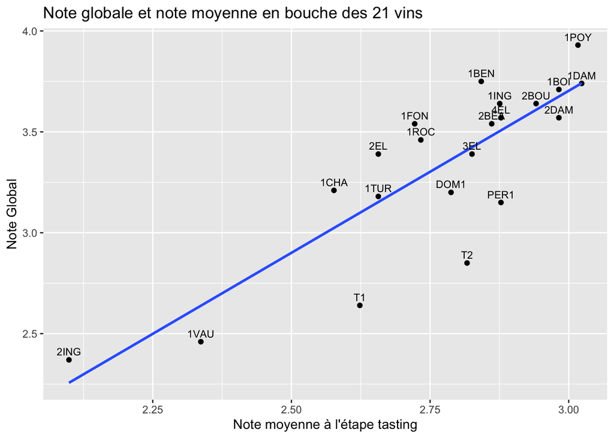

```r
ggplot(vins_global, aes(x = tasting, y = Global)) +
  geom_point() +
  geom_smooth(method = "lm", se = FALSE, formula = y ~ x) +
  geom_text(aes(label = Wines), vjust = -0.6, size = 3) +
  labs(x = "Note moyenne à l'étape tasting", y = "Note Global",
       title = "Note globale et note moyenne en bouche des 21 vins")
```

**Réponse :** oui, la note `Global` est fortement liée à la moyenne obtenue à l’étape `tasting` : le coefficient de corrélation de Pearson vaut **0,84**, soit une liaison positive et forte. Le test de corrélation donne une p-valeur de 1.9e-06, très inférieure à 5 % : la corrélation est significativement différente de 0. Les vins jugés bons en bouche sont donc aussi ceux qui ont une bonne note globale. Remarque : dans ce fichier, `Global` est strictement identique à la colonne `Assessor1`.

# Partie D : Nettoyer un fichier RH et joindre des tables

## D1

### Import

```r
emp <- read_csv("data/employee.csv", show_col_types = FALSE)
glimpse(emp)
```

```
## Rows: 235
## Columns: 9
## $ Employee_ID <dbl> 120101, 120104, 120105, 120106, 120107, 120108, 120108, 12…
## $ First       <chr> "Patrick", "Kareen", "Liz", "John", "Sherie", "Gladys", "G…
## $ Last        <chr> "Lu", "Billington", "Povey", "Hornsey", "Sheedy", "Gromek"…
## $ Gender      <chr> "M", "F", "F", "M", "F", "F", "F", "M", "M", "F", "F", "G"…
## $ Salary      <dbl> 163040, 46230, 27110, NA, 30475, 27660, 26495, 28615, 2689…
## $ Job_Title   <chr> "Director", "Administration Manager", "Secretary I", "Offi…
## $ Country     <chr> "AU", "au", "AU", "AU", "AU", "AU", "AU", "AU", "AU", "AU"…
## $ Birth_Date  <chr> "18/08/1976", "11/05/1954", "21/12/1974", "23/12/1944", "0…
## $ Hire_Date   <chr> "01/07/2003", "01/01/1981", "01/05/1999", "01/01/1974", "2…
```

```r
problems(emp)
```

```
## # A tibble: 0 × 5
## # ℹ 5 variables: row <int>, col <int>, expected <chr>, actual <chr>, file <chr>
```

Les dates (`Birth_Date`, `Hire_Date`) sont lues comme du texte (`character`), au format `jj/mm/aaaa`.

### Diagnostic

**Valeurs manquantes**

```r
colSums(is.na(emp))
```

```
## Employee_ID       First        Last      Gender      Salary   Job_Title
##           1           0           0           1           1           1
##     Country  Birth_Date   Hire_Date
##           0           0           1
```

```r
emp |> filter(if_any(everything(), is.na))   # les lignes concernées
```

```
## # A tibble: 5 × 9
##   Employee_ID First  Last   Gender Salary Job_Title Country Birth_Date Hire_Date
##         <dbl> <chr>  <chr>  <chr>   <dbl> <chr>     <chr>   <chr>      <chr>
## 1      120106 John   Horns… M          NA Office A… AU      23/12/1944 01/01/19…
## 2      120111 Ubaldo Spill… M       26895 Security… AU      23/07/1949 <NA>
## 3      120112 Ellis  Glatt… F       26550 <NA>      AU      17/02/1969 01/07/19…
## 4          NA Austen Ralst… M       29250 Service … AU      13/06/1959 01/02/19…
## 5      120723 Deanna Olsen  <NA>    33950 Corp. Co… US      10/08/1949 01/01/19…
```

**Codes incohérents**

```r
table(emp$Gender, useNA = "ifany")    # autre chose que F / M ?
```

```
##
##    F    G    M <NA>
##  110    1  123    1
```

```r
table(emp$Country, useNA = "ifany")   # majuscules et minuscules mélangées
```

```
##
##  au  AU  us  US
##   3  33   3 196
```

**Doublons**

```r
sum(duplicated(emp))                        # lignes strictement identiques
```

```
## [1] 0
```

```r
emp |> count(Employee_ID) |> filter(n > 1)  # identifiants en double
```

```
## # A tibble: 1 × 2
##   Employee_ID     n
##         <dbl> <int>
## 1      120108     2
```

```r
emp |> filter(Employee_ID %in% Employee_ID[duplicated(Employee_ID, incomparables = NA)]) |>
  select(Employee_ID, First, Last, Job_Title, Hire_Date)
```

```
## # A tibble: 2 × 5
##   Employee_ID First    Last   Job_Title              Hire_Date
##         <dbl> <chr>    <chr>  <chr>                  <chr>
## 1      120108 Gladys   Gromek Warehouse Assistant II 01/08/2006
## 2      120108 Gabriele Baker  Warehouse Assistant I  01/10/2006
```

**Valeurs impossibles ou aberrantes**

```r
summary(emp$Salary)
```

```
##    Min. 1st Qu.  Median    Mean 3rd Qu.    Max.     NAs
##    2401   27804   34020   43955   47252  433800       1
```

```r
emp |> filter(Salary < 10000) |> select(Employee_ID, First, Last, Job_Title, Salary)
```

```
## # A tibble: 2 × 5
##   Employee_ID First   Last        Job_Title           Salary
##         <dbl> <chr>   <chr>       <chr>                <dbl>
## 1      120115 Hugh    Nichollas   Service Assistant I   2650
## 2      120191 Jannene Graham-Rowe Trainee               2401
```

```r
emp |> slice_max(Salary, n = 3) |> select(First, Last, Job_Title, Salary)
```

```
## # A tibble: 3 × 4
##   First     Last     Job_Title               Salary
##   <chr>     <chr>    <chr>                    <dbl>
## 1 Anthony   Miller   Chief Executive Officer 433800
## 2 Max       Crown    Chief Financial Officer 268455
## 3 Christine Fletcher Chief Marketing Officer 207885
```

```r
# Dates : conversion temporaire pour contrôler leur cohérence
emp_dates <- emp |>
  mutate(naissance = dmy(Birth_Date),
         embauche  = dmy(Hire_Date),
         age_emb   = as.numeric(embauche - naissance) / 365.25)

range(emp_dates$naissance, na.rm = TRUE)
```

```
## [1] "1944-01-14" "1988-12-27"
```

```r
range(emp_dates$embauche, na.rm = TRUE)
```

```
## [1] "1953-01-21" "2006-12-01"
```

```r
# Embauches avant la création de l'enseigne (1974)
emp_dates |> filter(embauche < as.Date("1974-01-01")) |>
  select(Employee_ID, First, Last, Birth_Date, Hire_Date)
```

```
## # A tibble: 2 × 5
##   Employee_ID First  Last   Birth_Date Hire_Date
##         <dbl> <chr>  <chr>  <chr>      <chr>
## 1      120107 Sherie Sheedy 01/02/1978 21/01/1953
## 2      121011 Steven Banchi 11/03/1944 01/01/1968
```

```r
# Embauches à moins de 16 ans (dont avant la naissance)
emp_dates |> filter(age_emb < 16) |>
  select(Employee_ID, First, Last, Birth_Date, Hire_Date, age_emb)
```

```
## # A tibble: 3 × 6
##   Employee_ID First    Last   Birth_Date Hire_Date  age_emb
##         <dbl> <chr>    <chr>  <chr>      <chr>        <dbl>
## 1      120107 Sherie   Sheedy 01/02/1978 21/01/1953   -25.0
## 2      120277 Wesley   Shirts 16/08/1988 01/05/2004    15.7
## 3      120729 Kimberly Howell 03/04/1988 25/04/2003    15.1
```

### Bilan des anomalies

```r
anomalies <- tibble(
  anomalie = c(
    "Employee_ID manquant",
    "Employee_ID en double (2 personnes différentes)",
    "Lignes strictement identiques",
    "Gender manquant",
    "Gender incohérent (ni F ni M)",
    "Country en minuscules (au, us)",
    "Salary manquant",
    "Salary < 10 000 (zéro oublié ?)",
    "Job_Title manquant",
    "Hire_Date manquante",
    "Hire_Date antérieure à 1974 (création de l'enseigne)",
    "Embauche avant la naissance",
    "Embauche avant 16 ans (hors cas précédent)",
    "Dates stockées en texte"
  ),
  nb_lignes = c(
    sum(is.na(emp$Employee_ID)),
    sum(emp$Employee_ID %in% emp$Employee_ID[duplicated(emp$Employee_ID, incomparables = NA)]),
    sum(duplicated(emp)),
    sum(is.na(emp$Gender)),
    sum(!emp$Gender %in% c("F", "M") & !is.na(emp$Gender)),
    sum(emp$Country != toupper(emp$Country)),
    sum(is.na(emp$Salary)),
    sum(emp$Salary < 10000, na.rm = TRUE),
    sum(is.na(emp$Job_Title)),
    sum(is.na(emp$Hire_Date)),
    sum(emp_dates$embauche < as.Date("1974-01-01"), na.rm = TRUE),
    sum(emp_dates$embauche < emp_dates$naissance, na.rm = TRUE),
    sum(emp_dates$age_emb >= 0 & emp_dates$age_emb < 16, na.rm = TRUE),
    nrow(emp)
  )
)
knitr::kable(anomalies, col.names = c("Anomalie", "Lignes concernées"))
```

| Anomalie | Lignes concernées |
| --- | --- |
| Employee_ID manquant | 1 |
| Employee_ID en double (2 personnes différentes) | 2 |
| Lignes strictement identiques | 0 |
| Gender manquant | 1 |
| Gender incohérent (ni F ni M) | 1 |
| Country en minuscules (au, us) | 6 |
| Salary manquant | 1 |
| Salary < 10 000 (zéro oublié ?) | 2 |
| Job_Title manquant | 1 |
| Hire_Date manquante | 1 |
| Hire_Date antérieure à 1974 (création de l’enseigne) | 2 |
| Embauche avant la naissance | 1 |
| Embauche avant 16 ans (hors cas précédent) | 2 |
| Dates stockées en texte | 235 |

- **valeurs manquantes** : 1 en Employee_ID, 1 en Gender, 1 en Salary, 1 en Job_Title, 1 en Hire_Date, réparties sur 5 lignes ;
- **codes incohérents** : 1 genre codé `G` et 6 pays écrits en minuscules (au, us) ;
- **doublons** : aucune ligne strictement identique, mais l’identifiant 120108 est attribué à 2 personnes différentes (Gladys Gromek et Gabriele Baker) : c’est une erreur de saisie à signaler, pas une ligne à supprimer ;
- **salaires aberrants** : 2 salaires inférieurs à 10 000 (2 650 pour Service Assistant I, 2 401 pour Trainee), sans doute un zéro oublié. Le salaire maximal (433 800) est élevé mais plausible : c’est celui du Chief Executive Officer ;
- **dates impossibles** : 2 embauches antérieures à la création de l’enseigne en 1974 (21/01/1953 et 01/01/1968), dont 1 avant même la naissance de l’employé ; et 2 employés embauchés avant 16 ans (15,7 ans et 15,1 ans), ce qui est douteux ;
- **types** : les deux colonnes de dates sont stockées en texte et devront être converties.

## D2

### Pipeline de correction

```r
id_max <- max(emp$Employee_ID, na.rm = TRUE)   # plus grand identifiant existant

emp_propre <- emp |>
  mutate(
    # Pays : "au" / "us" -> "AU" / "US"
    Country = toupper(Country),

    # Genre : tout ce qui n'est pas F ou M ("G", valeur vide) devient NA
    Gender = if_else(Gender %in% c("F", "M"), Gender, NA),

    # Salaires < 10 000 : un zéro a manifestement été oublié à la saisie
    Salary = if_else(Salary < 10000, Salary * 10, Salary),

    # Texte "jj/mm/aaaa" -> Date
    Birth_Date = dmy(Birth_Date),
    Hire_Date  = dmy(Hire_Date),

    # Embauche avant la création de l'enseigne (1974) : impossible -> NA
    Hire_Date = if_else(Hire_Date < as.Date("1974-01-01"), NA, Hire_Date),

    # Employé sans identifiant : plus grand identifiant existant + 1
    Employee_ID = if_else(is.na(Employee_ID), id_max + 1, Employee_ID),

    # Âge à l'embauche en années révolues : nombre d'années complètes
    # écoulées entre la naissance et l'embauche
    age_embauche = interval(Birth_Date, Hire_Date) %/% years(1),

    # Ancienneté au 31/12/2007, en années complètes
    anciennete = interval(Hire_Date, as.Date("2007-12-31")) %/% years(1)
  )

glimpse(emp_propre)
```

```
## Rows: 235
## Columns: 11
## $ Employee_ID  <dbl> 120101, 120104, 120105, 120106, 120107, 120108, 120108, 1…
## $ First        <chr> "Patrick", "Kareen", "Liz", "John", "Sherie", "Gladys", "…
## $ Last         <chr> "Lu", "Billington", "Povey", "Hornsey", "Sheedy", "Gromek…
## $ Gender       <chr> "M", "F", "F", "M", "F", "F", "F", "M", "M", "F", "F", NA…
## $ Salary       <dbl> 163040, 46230, 27110, NA, 30475, 27660, 26495, 28615, 268…
## $ Job_Title    <chr> "Director", "Administration Manager", "Secretary I", "Off…
## $ Country      <chr> "AU", "AU", "AU", "AU", "AU", "AU", "AU", "AU", "AU", "AU…
## $ Birth_Date   <date> 1976-08-18, 1954-05-11, 1974-12-21, 1944-12-23, 1978-02-…
## $ Hire_Date    <date> 2003-07-01, 1981-01-01, 1999-05-01, 1974-01-01, NA, 2006…
## $ age_embauche <dbl> 26, 26, 24, 29, NA, 22, 19, 29, NA, 21, 29, 29, 21, 20, 2…
## $ anciennete   <dbl> 4, 26, 8, 33, NA, 1, 1, 28, NA, 17, 33, 33, 2, 27, 21, 23…
```

`interval(debut, fin) %/% years(1)` (lubridate) compte le nombre d’années **entières** entre deux dates, en tenant compte des années bissextiles et du jour d’anniversaire : c’est exactement l’âge « révolu ». Un simple `(fin - debut) / 365.25` donnerait un nombre décimal légèrement imprécis autour des anniversaires.

### Vérification : les anomalies de D1 ont-elles disparu ?

```r
verif <- tibble(
  anomalie = c(
    "Employee_ID manquant",
    "Gender autre que F / M / NA",
    "Country en minuscules",
    "Salary < 10 000",
    "Hire_Date antérieure à 1974",
    "Embauche avant la naissance",
    "Colonnes de dates stockées en texte"
  ),
  avant = c(
    sum(is.na(emp$Employee_ID)),
    sum(!emp$Gender %in% c("F", "M") & !is.na(emp$Gender)),
    sum(emp$Country != toupper(emp$Country)),
    sum(emp$Salary < 10000, na.rm = TRUE),
    sum(emp_dates$embauche < as.Date("1974-01-01"), na.rm = TRUE),
    sum(emp_dates$embauche < emp_dates$naissance, na.rm = TRUE),
    sum(sapply(emp[c("Birth_Date", "Hire_Date")], is.character))
  ),
  apres = c(
    sum(is.na(emp_propre$Employee_ID)),
    sum(!emp_propre$Gender %in% c("F", "M") & !is.na(emp_propre$Gender)),
    sum(emp_propre$Country != toupper(emp_propre$Country)),
    sum(emp_propre$Salary < 10000, na.rm = TRUE),
    sum(emp_propre$Hire_Date < as.Date("1974-01-01"), na.rm = TRUE),
    sum(emp_propre$Hire_Date < emp_propre$Birth_Date, na.rm = TRUE),
    sum(sapply(emp_propre[c("Birth_Date", "Hire_Date")], is.character))
  )
)
knitr::kable(verif, col.names = c("Anomalie", "Avant", "Après"))
```

| Anomalie | Avant | Après |
| --- | --- | --- |
| Employee_ID manquant | 1 | 0 |
| Gender autre que F / M / NA | 1 | 0 |
| Country en minuscules | 6 | 0 |
| Salary < 10 000 | 2 | 0 |
| Hire_Date antérieure à 1974 | 2 | 0 |
| Embauche avant la naissance | 1 | 0 |
| Colonnes de dates stockées en texte | 2 | 0 |

```r
# Contrôles complémentaires
table(emp_propre$Country)
```

```
##
##  AU  US
##  36 199
```

```r
table(emp_propre$Gender, useNA = "ifany")
```

```
##
##    F    M <NA>
##  110  123    2
```

```r
emp_propre |> filter(Employee_ID == id_max + 1) |> select(Employee_ID, First, Last)
```

```
## # A tibble: 1 × 3
##   Employee_ID First  Last
##         <dbl> <chr>  <chr>
## 1      121149 Austen Ralston
```

```r
emp_propre |> filter(Salary %in% (emp$Salary[emp$Salary < 10000 & !is.na(emp$Salary)] * 10)) |>
  select(Employee_ID, Job_Title, Salary)
```

```
## # A tibble: 2 × 3
##   Employee_ID Job_Title           Salary
##         <dbl> <chr>                <dbl>
## 1      120115 Service Assistant I  26500
## 2      120191 Trainee              24010
```

```r
summary(emp_propre$age_embauche)
```

```
##    Min. 1st Qu.  Median    Mean 3rd Qu.    Max.     NAs
##      15      20      24      24      27      48       3
```

```r
summary(emp_propre$anciennete)
```

```
##    Min. 1st Qu.  Median    Mean 3rd Qu.    Max.     NAs
##    1.00    4.00   14.00   15.30   25.25   33.00       3
```

**Réponse :** toutes les anomalies visées par les corrections ont disparu : la colonne « Après » vaut 0 partout. L’employé sans identifiant (Austen Ralston) a reçu l’identifiant 121149 (= 121148 + 1), les pays ne prennent plus que les valeurs AU et US, et `Gender` contient désormais 2 `NA` (l’ancien `G` et la valeur manquante). Les nouvelles colonnes `age_embauche` et `anciennete` sont manquantes pour les 3 employés sans date d’embauche valide.

Certaines anomalies de D1 ne faisaient pas partie des corrections demandées et **restent donc présentes** : l’identifiant 120108 toujours attribué à 2 personnes, le salaire manquant (1), l’intitulé de poste manquant (1), et les 2 employés embauchés à moins de 16 ans (voir D3d).

## D3

### a. Salaire médian par pays et par sexe

On écarte les 2 employés dont le genre est inconnu (`NA` depuis D2).

```r
salaire_pays_sexe <- emp_propre |>
  filter(!is.na(Gender)) |>
  summarise(salaire_median = median(Salary, na.rm = TRUE),
            effectif       = n(),
            .by = c(Country, Gender)) |>
  arrange(Country, Gender)
salaire_pays_sexe
```

```
## # A tibble: 4 × 4
##   Country Gender salaire_median effectif
##   <chr>   <chr>           <dbl>    <int>
## 1 AU      F               27110       15
## 2 AU      M               28090       20
## 3 US      F               36315       95
## 4 US      M               35870      103
```

```r
# Présentation : une colonne par sexe
salaire_pays_sexe |>
  select(-effectif) |>
  pivot_wider(names_from = Gender, values_from = salaire_median) |>
  mutate(ecart_F_M = F - M)
```

```
## # A tibble: 2 × 4
##   Country     F     M ecart_F_M
##   <chr>   <dbl> <dbl>     <dbl>
## 1 AU      27110 28090      -980
## 2 US      36315 35870       445
```

**Réponse :** en Australie, le salaire médian est de 27 110 pour les femmes et 28 090 pour les hommes ; aux États-Unis, de 36 315 pour les femmes et 35 870 pour les hommes. L’écart entre sexes est faible dans les deux pays (980 en Australie, en faveur des hommes ; 445 aux États-Unis, en faveur des femmes). L’écart entre pays est plus marqué : les salaires médians américains sont plus élevés d’environ 8 492. Attention, l’Australie ne compte que 35 employés contre 198 aux États-Unis.

### b. Les 5 intitulés de poste les plus fréquents

```r
top_postes <- emp_propre |>
  filter(!is.na(Job_Title)) |>
  summarise(effectif      = n(),
            salaire_moyen = mean(Salary, na.rm = TRUE),
            .by = Job_Title) |>
  slice_max(effectif, n = 5) |>      # ex aequo conservés
  arrange(desc(effectif), Job_Title)
top_postes
```

```
## # A tibble: 8 × 3
##   Job_Title              effectif salaire_moyen
##   <chr>                     <int>         <dbl>
## 1 Trainee                      18        25477.
## 2 Warehouse Assistant I        10        26262.
## 3 Purchasing Agent I            6        30977.
## 4 Accountant I                  5        31563
## 5 Accountant II                 5        37284
## 6 Marketing Assistant II        5        29544
## 7 Purchasing Agent II           5        34488
## 8 Shipping Manager              5        57477
```

**Réponse :** Trainee (18 employés, salaire moyen 25 477), Warehouse Assistant I (10 employés, salaire moyen 26 262), Purchasing Agent I (6 employés, salaire moyen 30 977) sont les postes les plus fréquents. Pour les places suivantes, 5 postes sont ex aequo avec 5 employés chacun : Accountant I (31 563), Accountant II (37 284), Marketing Assistant II (29 544), Purchasing Agent II (34 488), Shipping Manager (57 477). Plutôt que d’en choisir arbitrairement, on les garde tous, d’où 8 lignes. Les postes les plus fréquents sont des postes d’entrée (Trainee, assistants de niveau I), avec les salaires moyens les plus bas ; Shipping Manager se détache avec 57 477 en moyenne.

### c. Âge moyen à l’embauche par décennie

La décennie s’obtient en arrondissant l’année d’embauche à la dizaine inférieure : `floor(annee / 10) * 10` (1987 → 1980).

```r
age_decennie <- emp_propre |>
  filter(!is.na(Hire_Date)) |>
  mutate(decennie = floor(year(Hire_Date) / 10) * 10) |>
  summarise(age_moyen = mean(age_embauche),
            effectif  = n(),
            .by = decennie) |>
  arrange(decennie)
age_decennie
```

```
## # A tibble: 4 × 3
##   decennie age_moyen effectif
##      <dbl>     <dbl>    <int>
## 1     1970      25.8       51
## 2     1980      23.2       43
## 3     1990      23.8       60
## 4     2000      23.4       78
```

**Réponse :** l’âge moyen à l’embauche est de 25,8 ans dans les années 1970, 23,2 ans dans les années 1980, 23,8 ans dans les années 1990, 23,4 ans dans les années 2000. Les premiers employés, embauchés dans les années 1970 à l’ouverture de l’enseigne, étaient un peu plus âgés ; ensuite l’âge moyen se stabilise autour de 23 ans. Les 3 employés sans date d’embauche valide sont exclus.

### d. Âge minimal à l’embauche

```r
min(emp_propre$age_embauche, na.rm = TRUE)
```

```
## [1] 15
```

```r
moins_16 <- emp_propre |>
  filter(age_embauche < 16) |>
  select(Employee_ID, First, Last, Job_Title, Country, Birth_Date, Hire_Date, age_embauche)
moins_16
```

```
## # A tibble: 2 × 8
##   Employee_ID First   Last  Job_Title Country Birth_Date Hire_Date  age_embauche
##         <dbl> <chr>   <chr> <chr>     <chr>   <date>     <date>            <dbl>
## 1      120277 Wesley  Shir… Concessi… US      1988-08-16 2004-05-01           15
## 2      120729 Kimber… Howe… Purchasi… US      1988-04-03 2003-04-25           15
```

```r
# Combien d'employés sont nés la même année que ces deux-là, et à quel âge ont-ils été embauchés ?
emp_propre |>
  filter(year(Birth_Date) %in% year(moins_16$Birth_Date)) |>
  count(age_embauche)
```

```
## # A tibble: 4 × 2
##   age_embauche     n
##          <dbl> <int>
## 1           15     2
## 2           16     2
## 3           17     4
## 4           18     4
```

**Réponse :** l’âge minimal à l’embauche est de **15 ans**, et **2 employés** ont été embauchés avant 16 ans : Wesley Shirts (Concession Consultant I, US, embauché·e le 01/05/2004) et Kimberly Howell (Purchasing Agent I, US, embauché·e le 25/04/2003). C’est **peu plausible** : aux États-Unis, le travail avant 16 ans est strictement encadré (horaires limités, pas pendant le temps scolaire), ce qui cadre mal avec des postes de Concession Consultant I et de Purchasing Agent I dans une enseigne. Le plus probable est une **erreur de saisie** de la date de naissance ou d’embauche, à vérifier auprès du service RH plutôt qu’à corriger d’office. On remarque aussi que ces deux employés sont nés en 1988, l’année de naissance la plus récente du fichier : les 12 employés nés cette année-là ont tous été embauchés entre 15 et 18 ans, ce qui mérite aussi une vérification.

## D4

### a. Import et correspondance des clients

```r
commandes <- read_csv("data/commandes.csv", show_col_types = FALSE)
clients   <- read_csv("data/customer.csv",  show_col_types = FALSE)
dim(commandes)
```

```
## [1] 617  10
```

```r
dim(clients)
```

```
## [1] 77  9
```

```r
# Customer_ID est-il bien une clé (unique) dans le fichier clients ?
anyDuplicated(clients$Customer_ID)
```

```
## [1] 0
```

```r
# Lignes de commandes dont le client est absent du fichier clients
cmd_sans_client <- anti_join(commandes, clients, by = "Customer_ID")
nrow(cmd_sans_client)
```

```
## [1] 0
```

```r
# Dans l'autre sens : clients qui n'ont rien commandé
clients_sans_cmd <- anti_join(clients, commandes, by = "Customer_ID")
nrow(clients_sans_cmd)
```

```
## [1] 2
```

**Réponse :** oui : `anti_join()` renvoie 0 ligne, donc chacun des 75 clients différents présents dans les 617 lignes de commandes figure dans le fichier clients. `Customer_ID` est bien unique dans le fichier clients (`anyDuplicated()` vaut 0), ce qui garantit que la jointure ne dupliquera pas de lignes. À l’inverse, 2 des 77 clients n’ont passé aucune commande.

### b. Pays et sexe du client, CA par pays

```r
cmd_clients <- commandes |>
  left_join(select(clients, Customer_ID, Country, Gender), by = "Customer_ID")
nrow(cmd_clients) == nrow(commandes)   # aucune ligne ajoutée ni perdue
```

```
## [1] TRUE
```

```r
ca_pays <- cmd_clients |>
  summarise(ca = sum(Total_Retail_Price), .by = Country) |>
  mutate(part = ca / sum(ca)) |>
  arrange(desc(ca))
ca_pays
```

```
## # A tibble: 7 × 3
##   Country     ca   part
##   <chr>    <dbl>  <dbl>
## 1 US      43525. 0.435
## 2 AU      17321. 0.173
## 3 DE      15395. 0.154
## 4 CA      11951. 0.119
## 5 TR       5176. 0.0517
## 6 ZA       5150. 0.0515
## 7 IL       1560. 0.0156
```

**Réponse :** le chiffre d’affaires total est de 100 077 dollars. Par pays de client : US 43 525 (43,5 %), AU 17 321 (17,3 %), DE 15 395 (15,4 %), CA 11 951 (11,9 %), TR 5 176 (5,2 %), ZA 5 150 (5,1 %), IL 1 560 (1,6 %). Les clients américains représentent **43,5 % du CA**, la première part, devant AU (17,3 %).

### c. Lien avec le fichier RH

On ne garde que les ventes **avec** vendeur (`Employee_ID` différent de `99999999`), puis on regarde lesquelles retrouvent leur vendeur dans `emp_propre`. `semi_join()` garde les lignes qui ont une correspondance, `anti_join()` celles qui n’en ont pas, sans ajouter de colonnes ni dupliquer de lignes.

```r
cmd_vendeur <- commandes |> filter(Employee_ID != 99999999)
nrow(cmd_vendeur)
```

```
## [1] 324
```

```r
n_distinct(cmd_vendeur$Employee_ID)        # nombre de vendeurs différents
```

```
## [1] 100
```

```r
avec_rh <- semi_join(cmd_vendeur, emp_propre, by = "Employee_ID")
sans_rh <- anti_join(cmd_vendeur, emp_propre, by = "Employee_ID")
nrow(avec_rh)
```

```
## [1] 15
```

```r
nrow(sans_rh)
```

```
## [1] 309
```

```r
n_distinct(avec_rh$Employee_ID)            # vendeurs retrouvés
```

```
## [1] 7
```

```r
# Les identifiants des vendeurs sont-ils dans la même plage que ceux du fichier RH ?
range(cmd_vendeur$Employee_ID)
```

```
## [1] 120121 121140
```

```r
range(emp_propre$Employee_ID)
```

```
## [1] 120101 121149
```

**Réponse :** sur les 324 lignes de commandes avec vendeur (100 vendeurs différents), seules **15 lignes** (4,6 %) retrouvent leur vendeur dans `emp_propre`, ce qui correspond à 7 vendeurs seulement ; 309 lignes n’ont pas de correspondance. Les identifiants sont pourtant du même format et dans la même plage de valeurs : ce n’est pas un problème de codage de la clé. On en conclut que les deux fichiers **ne couvrent pas le même périmètre** : `employee.csv` ne contient qu’une partie du personnel (235 employés), alors que les commandes font intervenir de nombreux vendeurs absents de ce fichier. Les deux tables ne sont donc pas cohérentes entre elles : toute analyse des ventes par vendeur à partir de ces fichiers ne portera que sur une petite fraction des ventes et devra être interprétée avec prudence.

### d. Vendeur au plus gros CA

On calcule le CA par vendeur sur les lignes dont le vendeur est identifié, puis on récupère son nom et son poste par jointure. Avant de joindre, on vérifie que `Employee_ID` est unique dans `emp_propre` pour les vendeurs concernés (l’identifiant en double, 120108, pourrait sinon dupliquer des lignes).

```r
# Identifiants en double parmi les vendeurs retrouvés ?
emp_propre |>
  filter(Employee_ID %in% avec_rh$Employee_ID) |>
  count(Employee_ID) |>
  filter(n > 1)
```

```
## # A tibble: 0 × 2
## # ℹ 2 variables: Employee_ID <dbl>, n <int>
```

```r
ca_vendeur <- avec_rh |>
  summarise(ca = sum(Total_Retail_Price),
            nb_lignes = n(),
            .by = Employee_ID) |>
  left_join(select(emp_propre, Employee_ID, First, Last, Job_Title, Country),
            by = "Employee_ID") |>
  arrange(desc(ca))
ca_vendeur
```

```
## # A tibble: 7 × 7
##   Employee_ID    ca nb_lignes First   Last       Job_Title            Country
##         <dbl> <dbl>     <int> <chr>   <chr>      <chr>                <chr>
## 1      120732 668.          4 Kent    Uenking    Purchasing Agent III US
## 2      120733 619.          4 Michael Bezinque   Purchasing Agent I   US
## 3      120190 240           1 Ivor    Czernezkyi Trainee              AU
## 4      120195 224.          3 Jina    Fiocca     Trainee              AU
## 5      121127 179.          1 Keyna   Mangini    Trainee              US
## 6      120192 124.          1 Anthony Nichollas  Trainee              AU
## 7      120734  40.2         1 Svein   Saylor     Purchasing Agent III US
```

```r
meilleur_vendeur <- ca_vendeur |> slice_max(ca, n = 1)
meilleur_vendeur
```

```
## # A tibble: 1 × 7
##   Employee_ID    ca nb_lignes First Last    Job_Title            Country
##         <dbl> <dbl>     <int> <chr> <chr>   <chr>                <chr>
## 1      120732  668.         4 Kent  Uenking Purchasing Agent III US
```

**Réponse :** parmi les 7 vendeurs identifiés, celui qui a réalisé le plus gros CA est **Kent Uenking**, Purchasing Agent III (US), avec 668,10 dollars sur 4 lignes de commande. Ce classement ne porte toutefois que sur les 15 lignes retrouvées dans le fichier RH (question c) : le « meilleur vendeur » de l’enseigne peut très bien faire partie des vendeurs absents de `employee.csv`.